# QK Box 9.3 and 9.4

This example continues from Box 9.1 and earlier

A regression tree for the data from Loyn (1987) related the abundance of forest birds in 56 forest fragments to log patch area, log distance to nearest patch, grazing intensity, altitude and year of isolation. Transformations of predictors to improve linearity are unnecessary for regression trees (and made almost no difference to this specific analysis) but we kept these predictors transformed to match our previous analyses of these data (Boxes 8.2 and 9.1). We used the anova method of maximizing the between-groups SS for each split and used a change in r2 of 0.01 as a default cp value. No other tree-building constraints were imposed. The residual plot from fitting the regression tree did not reveal any strong variance heterogeneity nor outliers.

### Preliminaries

First, load the required packages (need rpart, randomForest, Metrics, gbm, dismo, caret)

Import loyn data file (loyn.csv) and log-transform area & dist

```r
loyn <- read.csv("../data/loyn.csv")
head(loyn,10)
```

|  | abund | area | yearisol | dist | distl | graze | alt |
| --- | --- | --- | --- | --- | --- | --- | --- |
| 1 | 5.3 | 0.1 | 1968 | 39 | 39 | 2 | 160 |
| 2 | 2.0 | 0.5 | 1920 | 234 | 234 | 5 | 60 |
| 3 | 1.5 | 0.5 | 1900 | 104 | 311 | 5 | 140 |
| 4 | 17.1 | 1.0 | 1966 | 66 | 66 | 3 | 160 |
| 5 | 13.8 | 1.0 | 1918 | 246 | 246 | 5 | 140 |
| 6 | 14.1 | 1.0 | 1965 | 234 | 285 | 3 | 130 |
| 7 | 3.8 | 1.0 | 1955 | 467 | 467 | 5 | 90 |
| 8 | 2.2 | 1.0 | 1920 | 284 | 1829 | 5 | 60 |
| 9 | 3.3 | 1.0 | 1965 | 156 | 156 | 4 | 130 |
| 10 | 3.0 | 1.0 | 1900 | 311 | 571 | 5 | 130 |

```r
loyn$logarea <- log10(loyn$area)
loyn$logdist <- log10(loyn$dist)
```

## Fit regression tree

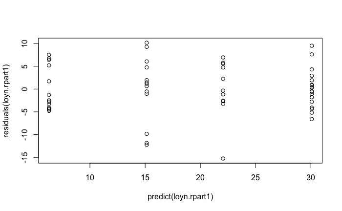

```r
loyn.rpart1 <- rpart(abund~ logarea+logdist+graze+alt+yearisol, data=loyn, method="anova")
plot(predict(loyn.rpart1),residuals(loyn.rpart1))
```

```r
loyn.rpart1
```

```
n= 56

node), split, n, deviance, yval
      * denotes terminal node

 1) root 56 6337.9290 19.514290
   2) graze>=4.5 13  277.2892  6.292308 *
   3) graze< 4.5 43 3100.8840 23.511630
     6) logarea< 1.145017 24 1327.1980 18.308330
      12) yearisol>=1964 13  644.3108 15.138460 *
      13) yearisol< 1964 11  397.8873 22.054550 *
     7) logarea>=1.145017 19  303.1253 30.084210 *
```

```r
summary(loyn.rpart1)
```

```
Call:
rpart(formula = abund ~ logarea + logdist + graze + alt + yearisol,
    data = loyn, method = "anova")
  n= 56

          CP nsplit rel error    xerror       xstd
1 0.46699093      0 1.0000000 1.0320747 0.13421804
2 0.23202543      1 0.5330091 0.7706083 0.12636285
3 0.04496742      2 0.3009836 0.5479940 0.09493545
4 0.01000000      3 0.2560162 0.4129901 0.06721846

Variable importance
   graze yearisol  logarea      alt  logdist
      37       29       20        8        5

Node number 1: 56 observations,    complexity param=0.4669909
  mean=19.51429, MSE=113.1773
  left son=2 (13 obs) right son=3 (43 obs)
  Primary splits:
      graze    < 4.5       to the right, improve=0.46699090, (0 missing)
      logarea  < 1.020696  to the left,  improve=0.45988770, (0 missing)
      yearisol < 1924.5    to the left,  improve=0.38557730, (0 missing)
      alt      < 162.5     to the left,  improve=0.21282890, (0 missing)
      logdist  < 2.594916  to the left,  improve=0.05050402, (0 missing)
  Surrogate splits:
      yearisol < 1924.5    to the left,  agree=0.964, adj=0.846, (0 split)
      alt      < 95        to the left,  agree=0.821, adj=0.231, (0 split)
      logarea  < 0.150515  to the left,  agree=0.804, adj=0.154, (0 split)

Node number 2: 13 observations
  mean=6.292308, MSE=21.32994

Node number 3: 43 observations,    complexity param=0.2320254
  mean=23.51163, MSE=72.11359
  left son=6 (24 obs) right son=7 (19 obs)
  Primary splits:
      logarea  < 1.145017  to the left,  improve=0.47423910, (0 missing)
      graze    < 1.5       to the right, improve=0.15699760, (0 missing)
      alt      < 162.5     to the left,  improve=0.08926499, (0 missing)
      yearisol < 1964.5    to the right, improve=0.06537171, (0 missing)
```

[output cut: 14 more lines]

```
      graze    < 2.5       to the left,  improve=0.0002803762, (0 missing)
  Surrogate splits:
      logarea < 0.7385606 to the left,  agree=0.708, adj=0.364, (0 split)
      graze   < 2.5       to the left,  agree=0.667, adj=0.273, (0 split)
      alt     < 115       to the right, agree=0.667, adj=0.273, (0 split)
      logdist < 2.144102  to the right, agree=0.625, adj=0.182, (0 split)

Node number 7: 19 observations
  mean=30.08421, MSE=15.95396

Node number 12: 13 observations
  mean=15.13846, MSE=49.56237

Node number 13: 11 observations
  mean=22.05455, MSE=36.17157
```

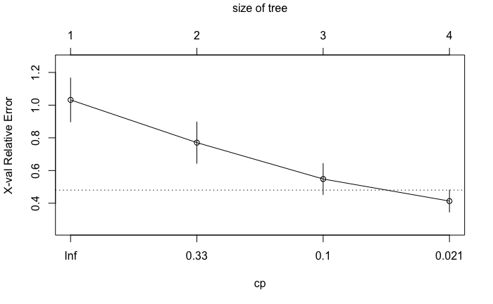

```r
plotcp(loyn.rpart1)
```

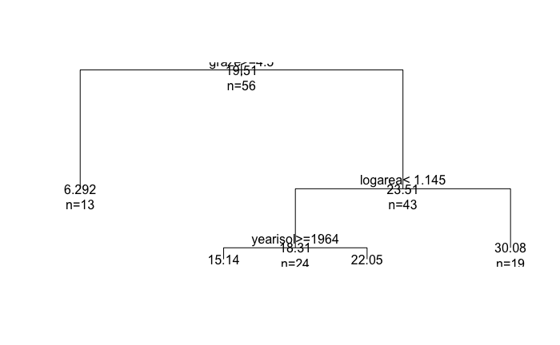

```r
plot(loyn.rpart1)
text(loyn.rpart1, use.n=TRUE, all=TRUE)
```

### Variable importance from caret

```r
varImp(loyn.rpart1)
```

|  | Overall |
| --- | --- |
| alt | 0.4378265 |
| graze | 0.6242689 |
| logarea | 1.0520836 |
| logdist | 0.1284961 |
| yearisol | 0.6656873 |

### Try a lower cp - no difference in resulting tree

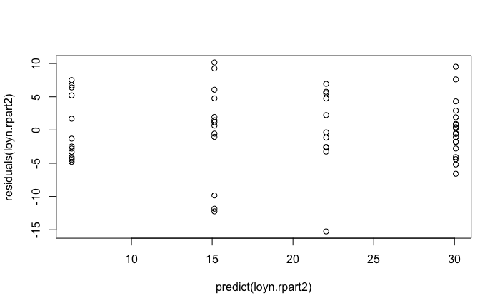

```r
loyn.rpart2 <- rpart(abund~ logarea+logdist+graze+alt+yearisol, data=loyn, method="anova", cp=0.005)
plot(predict(loyn.rpart2),residuals(loyn.rpart2))
```

```r
summary(loyn.rpart2)
```

```
Call:
rpart(formula = abund ~ logarea + logdist + graze + alt + yearisol,
    data = loyn, method = "anova", cp = 0.005)
  n= 56

          CP nsplit rel error    xerror       xstd
1 0.46699093      0 1.0000000 1.0301639 0.13181018
2 0.23202543      1 0.5330091 0.7220963 0.10566076
3 0.04496742      2 0.3009836 0.4215349 0.07673234
4 0.00500000      3 0.2560162 0.3481076 0.06449313

Variable importance
   graze yearisol  logarea      alt  logdist
      37       29       20        8        5

Node number 1: 56 observations,    complexity param=0.4669909
  mean=19.51429, MSE=113.1773
  left son=2 (13 obs) right son=3 (43 obs)
  Primary splits:
      graze    < 4.5       to the right, improve=0.46699090, (0 missing)
      logarea  < 1.020696  to the left,  improve=0.45988770, (0 missing)
      yearisol < 1924.5    to the left,  improve=0.38557730, (0 missing)
      alt      < 162.5     to the left,  improve=0.21282890, (0 missing)
      logdist  < 2.594916  to the left,  improve=0.05050402, (0 missing)
  Surrogate splits:
      yearisol < 1924.5    to the left,  agree=0.964, adj=0.846, (0 split)
      alt      < 95        to the left,  agree=0.821, adj=0.231, (0 split)
      logarea  < 0.150515  to the left,  agree=0.804, adj=0.154, (0 split)

Node number 2: 13 observations
  mean=6.292308, MSE=21.32994

Node number 3: 43 observations,    complexity param=0.2320254
  mean=23.51163, MSE=72.11359
  left son=6 (24 obs) right son=7 (19 obs)
  Primary splits:
      logarea  < 1.145017  to the left,  improve=0.47423910, (0 missing)
      graze    < 1.5       to the right, improve=0.15699760, (0 missing)
      alt      < 162.5     to the left,  improve=0.08926499, (0 missing)
      yearisol < 1964.5    to the right, improve=0.06537171, (0 missing)
```

[output cut: 14 more lines]

```
      graze    < 2.5       to the left,  improve=0.0002803762, (0 missing)
  Surrogate splits:
      logarea < 0.7385606 to the left,  agree=0.708, adj=0.364, (0 split)
      graze   < 2.5       to the left,  agree=0.667, adj=0.273, (0 split)
      alt     < 115       to the right, agree=0.667, adj=0.273, (0 split)
      logdist < 2.144102  to the right, agree=0.625, adj=0.182, (0 split)

Node number 7: 19 observations
  mean=30.08421, MSE=15.95396

Node number 12: 13 observations
  mean=15.13846, MSE=49.56237

Node number 13: 11 observations
  mean=22.05455, MSE=36.17157
```

```r
print(loyn.rpart2)
```

```
n= 56

node), split, n, deviance, yval
      * denotes terminal node

 1) root 56 6337.9290 19.514290
   2) graze>=4.5 13  277.2892  6.292308 *
   3) graze< 4.5 43 3100.8840 23.511630
     6) logarea< 1.145017 24 1327.1980 18.308330
      12) yearisol>=1964 13  644.3108 15.138460 *
      13) yearisol< 1964 11  397.8873 22.054550 *
     7) logarea>=1.145017 19  303.1253 30.084210 *
```

```r
printcp(loyn.rpart2)
```

```
Regression tree:
rpart(formula = abund ~ logarea + logdist + graze + alt + yearisol,
    data = loyn, method = "anova", cp = 0.005)

Variables actually used in tree construction:
[1] graze    logarea  yearisol

Root node error: 6337.9/56 = 113.18

n= 56

        CP nsplit rel error  xerror     xstd
1 0.466991      0   1.00000 1.03016 0.131810
2 0.232025      1   0.53301 0.72210 0.105661
3 0.044967      2   0.30098 0.42153 0.076732
4 0.005000      3   0.25602 0.34811 0.064493
```

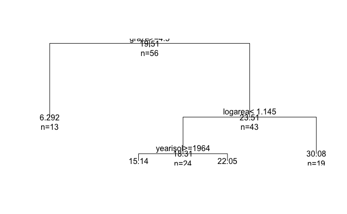

```r
plot(loyn.rpart2)
text(loyn.rpart2, use.n=TRUE, all=TRUE)
```

### Use untramsformed predictors - almost identical to first tree

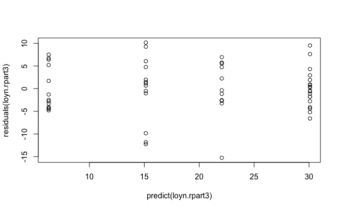

```r
loyn.rpart3 <- rpart(abund~ area+dist+graze+alt+yearisol, data=loyn, method="anova")
plot(predict(loyn.rpart3),residuals(loyn.rpart3))
```

```r
summary(loyn.rpart3)
```

```
Call:
rpart(formula = abund ~ area + dist + graze + alt + yearisol,
    data = loyn, method = "anova")
  n= 56

          CP nsplit rel error    xerror       xstd
1 0.46699093      0 1.0000000 1.0367970 0.13348951
2 0.23202543      1 0.5330091 0.8387713 0.12886575
3 0.04496742      2 0.3009836 0.4665100 0.08564323
4 0.01000000      3 0.2560162 0.4591197 0.08497119

Variable importance
   graze yearisol     area      alt     dist
      37       29       20        8        5

Node number 1: 56 observations,    complexity param=0.4669909
  mean=19.51429, MSE=113.1773
  left son=2 (13 obs) right son=3 (43 obs)
  Primary splits:
      graze    < 4.5    to the right, improve=0.46699090, (0 missing)
      area     < 10.5   to the left,  improve=0.45988770, (0 missing)
      yearisol < 1924.5 to the left,  improve=0.38557730, (0 missing)
      alt      < 162.5  to the left,  improve=0.21282890, (0 missing)
      dist     < 393.5  to the left,  improve=0.05050402, (0 missing)
  Surrogate splits:
      yearisol < 1924.5 to the left,  agree=0.964, adj=0.846, (0 split)
      alt      < 95     to the left,  agree=0.821, adj=0.231, (0 split)
      area     < 1.5    to the left,  agree=0.804, adj=0.154, (0 split)

Node number 2: 13 observations
  mean=6.292308, MSE=21.32994

Node number 3: 43 observations,    complexity param=0.2320254
  mean=23.51163, MSE=72.11359
  left son=6 (24 obs) right son=7 (19 obs)
  Primary splits:
      area     < 14     to the left,  improve=0.47423910, (0 missing)
      graze    < 1.5    to the right, improve=0.15699760, (0 missing)
      alt      < 162.5  to the left,  improve=0.08926499, (0 missing)
      yearisol < 1964.5 to the right, improve=0.06537171, (0 missing)
```

[output cut: 14 more lines]

```
      graze    < 2.5    to the left,  improve=0.0002803762, (0 missing)
  Surrogate splits:
      area  < 5.5    to the left,  agree=0.708, adj=0.364, (0 split)
      graze < 2.5    to the left,  agree=0.667, adj=0.273, (0 split)
      alt   < 115    to the right, agree=0.667, adj=0.273, (0 split)
      dist  < 139.5  to the right, agree=0.625, adj=0.182, (0 split)

Node number 7: 19 observations
  mean=30.08421, MSE=15.95396

Node number 12: 13 observations
  mean=15.13846, MSE=49.56237

Node number 13: 11 observations
  mean=22.05455, MSE=36.17157
```

```r
print(loyn.rpart3)
```

```
n= 56

node), split, n, deviance, yval
      * denotes terminal node

 1) root 56 6337.9290 19.514290
   2) graze>=4.5 13  277.2892  6.292308 *
   3) graze< 4.5 43 3100.8840 23.511630
     6) area< 14 24 1327.1980 18.308330
      12) yearisol>=1964 13  644.3108 15.138460 *
      13) yearisol< 1964 11  397.8873 22.054550 *
     7) area>=14 19  303.1253 30.084210 *
```

```r
loyn.rpart3$variable.importance
```

```
    graze  yearisol      area       alt      dist
3734.0638 2944.2044 2029.5440  760.7478  516.2058
```

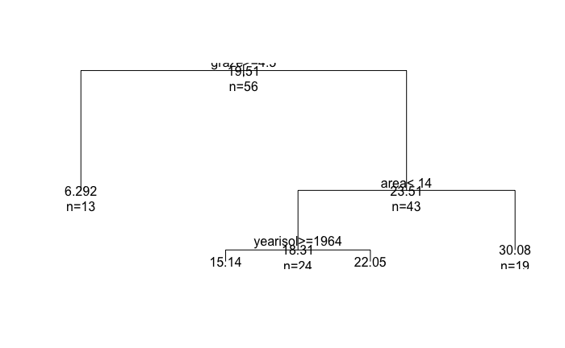

```r
plot(loyn.rpart3)
text(loyn.rpart3, use.n=TRUE, all=TRUE)
```

## Do bagged regression tree

```r
loyn.bag <- randomForest(abund~ logarea+logdist+graze+alt+yearisol, mtry=5, data=loyn)
print(loyn.bag)
```

```
Call:
 randomForest(formula = abund ~ logarea + logdist + graze + alt +      yearisol, data = loyn, mtry = 5)
               Type of random forest: regression
                     Number of trees: 500
No. of variables tried at each split: 5

          Mean of squared residuals: 44.975
                    % Var explained: 60.26
```

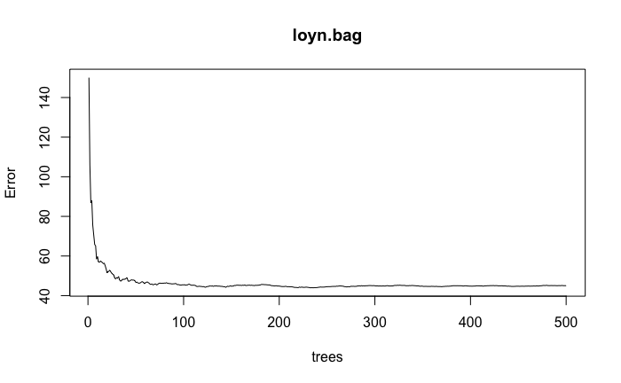

```r
plot(loyn.bag)
```

## Do random forest using 2 predictors chosen randomly at a time

```r
loyn.forest <- randomForest(abund~ logarea+logdist+graze+alt+yearisol, mtry=2, data=loyn)
print(loyn.forest)
```

```
Call:
 randomForest(formula = abund ~ logarea + logdist + graze + alt +      yearisol, data = loyn, mtry = 2)
               Type of random forest: regression
                     Number of trees: 500
No. of variables tried at each split: 2

          Mean of squared residuals: 46.64511
                    % Var explained: 58.79
```

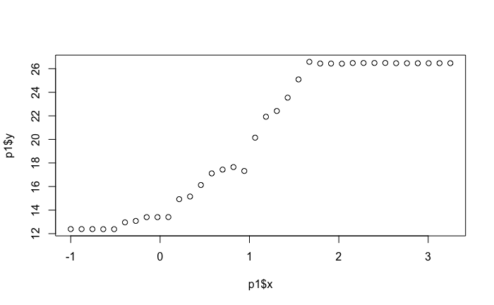

```r
p1<-partialPlot(loyn.forest,loyn, x.var="logarea", plot=FALSE)
plot(p1)
```

### Compare RMSE to single rpart tree with no pruning (cp=0)

```r
loyn.rpart1a <- rpart(abund~ logarea+logdist+graze+alt+yearisol, data=loyn, method="anova", cp=0)
summary(loyn.rpart1a)
```

```
Call:
rpart(formula = abund ~ logarea + logdist + graze + alt + yearisol,
    data = loyn, method = "anova", cp = 0)
  n= 56

          CP nsplit rel error    xerror       xstd
1 0.46699093      0 1.0000000 1.0825597 0.14255613
2 0.23202543      1 0.5330091 0.8500160 0.11139568
3 0.04496742      2 0.3009836 0.4513146 0.08382967
4 0.00000000      3 0.2560162 0.3856313 0.07389802

Variable importance
   graze yearisol  logarea      alt  logdist
      37       29       20        8        5

Node number 1: 56 observations,    complexity param=0.4669909
  mean=19.51429, MSE=113.1773
  left son=2 (13 obs) right son=3 (43 obs)
  Primary splits:
      graze    < 4.5       to the right, improve=0.46699090, (0 missing)
      logarea  < 1.020696  to the left,  improve=0.45988770, (0 missing)
      yearisol < 1924.5    to the left,  improve=0.38557730, (0 missing)
      alt      < 162.5     to the left,  improve=0.21282890, (0 missing)
      logdist  < 2.594916  to the left,  improve=0.05050402, (0 missing)
  Surrogate splits:
      yearisol < 1924.5    to the left,  agree=0.964, adj=0.846, (0 split)
      alt      < 95        to the left,  agree=0.821, adj=0.231, (0 split)
      logarea  < 0.150515  to the left,  agree=0.804, adj=0.154, (0 split)

Node number 2: 13 observations
  mean=6.292308, MSE=21.32994

Node number 3: 43 observations,    complexity param=0.2320254
  mean=23.51163, MSE=72.11359
  left son=6 (24 obs) right son=7 (19 obs)
  Primary splits:
      logarea  < 1.145017  to the left,  improve=0.47423910, (0 missing)
      graze    < 1.5       to the right, improve=0.15699760, (0 missing)
      alt      < 162.5     to the left,  improve=0.08926499, (0 missing)
      yearisol < 1964.5    to the right, improve=0.06537171, (0 missing)
```

[output cut: 14 more lines]

```
      graze    < 2.5       to the left,  improve=0.0002803762, (0 missing)
  Surrogate splits:
      logarea < 0.7385606 to the left,  agree=0.708, adj=0.364, (0 split)
      graze   < 2.5       to the left,  agree=0.667, adj=0.273, (0 split)
      alt     < 115       to the right, agree=0.667, adj=0.273, (0 split)
      logdist < 2.144102  to the right, agree=0.625, adj=0.182, (0 split)

Node number 7: 19 observations
  mean=30.08421, MSE=15.95396

Node number 12: 13 observations
  mean=15.13846, MSE=49.56237

Node number 13: 11 observations
  mean=22.05455, MSE=36.17157
```

```r
loyn.rpart1a.predict <- xpred.rpart(loyn.rpart1a)
rmsqe1a <- rmse(loyn$abund, loyn.rpart1a.predict)
rmsqe1a
```

```
[1] 8.70802
```

### Compare to RMSE of actual final tree based on cp=0.01

```r
loyn.rpart1.predict <- xpred.rpart(loyn.rpart1)
rmsqe1 <- rmse(loyn$abund, loyn.rpart1.predict)
rmsqe1
```

```
[1] 9.409801
```

## Boosted regression tree - using dismo first set learning rate and complexity

```
 GBM STEP - version 2.9

Performing cross-validation optimisation of a boosted regression tree model
for abund and using a family of gaussian
Using 56 observations and 5 predictors
creating 10 initial models of 50 trees

 folds are unstratified
total mean deviance =  113.1773
tolerance is fixed at  0.1132
ntrees resid. dev.
50    89.3083
now adding trees...
100   72.9216
150   63.0143
200   57.4608
250   54.4914
300   53.0836
350   52.3106
400   52.2914
450   52.3397
500   52.211
550   52.2842
600   52.4289
650   52.5697
700   52.488
750   52.4548
800   53.1704
850   53.2053
900   53.1251
950   53.504
1000   53.747
1050   53.8292
1100   53.8188
1150   54.0263

mean total deviance = 113.177
mean residual deviance = 29.257

estimated cv deviance = 52.211 ; se = 6.729

training data correlation = 0.865
cv correlation =  0.714 ; se = 0.059

elapsed time -  0.01 minutes
```

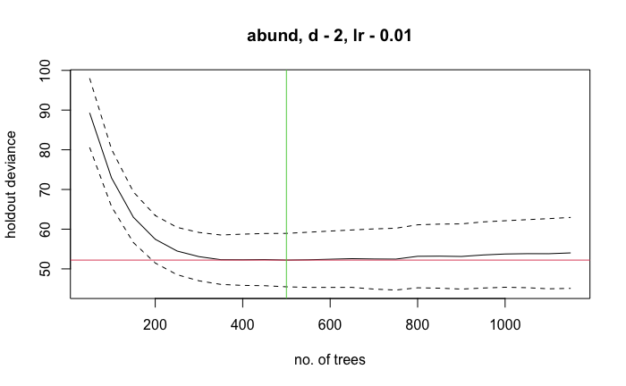

```r
loyn.gbm <- gbm.step(gbm.y=1, gbm.x=c(3,6:9), data=loyn, family="gaussian", bag.fraction=0.5, learning.rate=0.01, tree.complexity=2)
```

```r
print(loyn.gbm)
```

```
gbm::gbm(formula = y.data ~ ., distribution = as.character(family),
    data = x.data, weights = site.weights, var.monotone = var.monotone,
    n.trees = target.trees, interaction.depth = tree.complexity,
    shrinkage = learning.rate, bag.fraction = bag.fraction, verbose = FALSE)
A gradient boosted model with gaussian loss function.
500 iterations were performed.
There were 5 predictors of which 5 had non-zero influence.
```

### Try smaller learning rate to get above 1000 trees

```
 GBM STEP - version 2.9

Performing cross-validation optimisation of a boosted regression tree model
for abund and using a family of gaussian
Using 56 observations and 5 predictors
creating 10 initial models of 50 trees

 folds are unstratified
total mean deviance =  113.1773
tolerance is fixed at  0.1132
ntrees resid. dev.
50    98.2031
now adding trees...
100   85.2911
150   76.154
200   69.2657
250   64.0741
300   60.2071
350   56.9562
400   54.6287
450   52.802
500   51.5601
550   50.3817
600   49.6615
650   49.2383
700   48.9079
750   48.6573
800   48.3074
850   48.0518
900   47.9464
950   47.8624
1000   47.8151
1050   47.601
1100   47.3847
1150   47.2743
1200   47.1666
1250   47.234
1300   47.163
1350   47.0592
1400   47.0506
```

[output cut: 8 more lines]

```
1850   47.0915
1900   47.086
1950   46.9991
2000   47.068
2050   46.9666

mean total deviance = 113.177
mean residual deviance = 24.499

estimated cv deviance = 46.967 ; se = 11.725

training data correlation = 0.886
cv correlation =  0.725 ; se = 0.083

elapsed time -  0.01 minutes
```

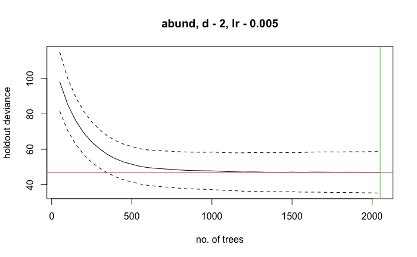

```r
loyn.gbm1 <- gbm.step(gbm.y=1, gbm.x=c(3,6:9), data=loyn, family="gaussian", bag.fraction=0.5, learning.rate=0.005, tree.complexity=2)
```

```r
print(loyn.gbm1)
```

```
gbm::gbm(formula = y.data ~ ., distribution = as.character(family),
    data = x.data, weights = site.weights, var.monotone = var.monotone,
    n.trees = target.trees, interaction.depth = tree.complexity,
    shrinkage = learning.rate, bag.fraction = bag.fraction, verbose = FALSE)
A gradient boosted model with gaussian loss function.
2050 iterations were performed.
There were 5 predictors of which 5 had non-zero influence.
```

**this is chosen model to calculate RMSE**

```r
rmsqe2 <- sqrt(min(loyn.gbm1$cv.values))
rmsqe2
```

```
[1] 6.853216
```

## Do partial dependence plots which include variable importance - all on one page

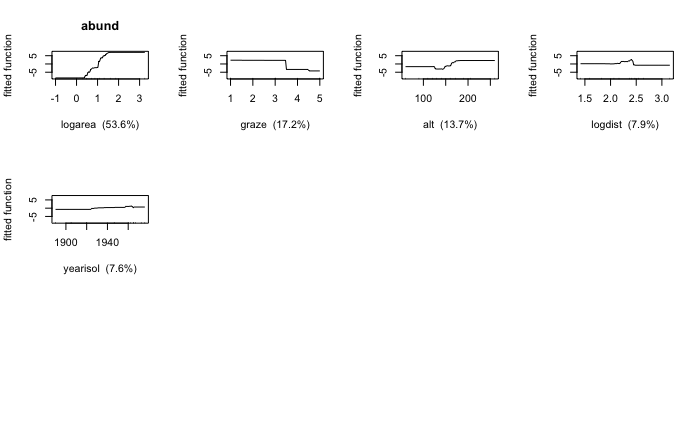

```r
gbm.plot(loyn.gbm1, variable.no=0)
```

**Try simpler tree (complexity=1)**

```
 GBM STEP - version 2.9

Performing cross-validation optimisation of a boosted regression tree model
for abund and using a family of gaussian
Using 56 observations and 5 predictors
creating 10 initial models of 50 trees

 folds are unstratified
total mean deviance =  113.1773
tolerance is fixed at  0.1132
ntrees resid. dev.
50    99.5682
now adding trees...
100   86.426
150   76.865
200   69.142
250   63.7006
300   59.5133
350   56.3968
400   53.8642
450   52.0525
500   50.8655
550   49.9187
600   49.0016
650   48.3989
700   47.8276
750   47.5905
800   47.4264
850   47.3482
900   47.1419
950   47.2081
1000   46.9313
1050   46.6394
1100   46.6729
1150   46.6331
1200   46.6716
1250   46.6434
1300   46.5478
1350   46.6361
1400   46.7768
1450   46.7217
1500   46.7073
1550   46.7598
1600   46.9478
1650   46.9548
1700   46.9556
1750   46.8729

mean total deviance = 113.177
mean residual deviance = 27.461

estimated cv deviance = 46.548 ; se = 10.273

training data correlation = 0.872
cv correlation =  0.745 ; se = 0.083

elapsed time -  0.01 minutes
```

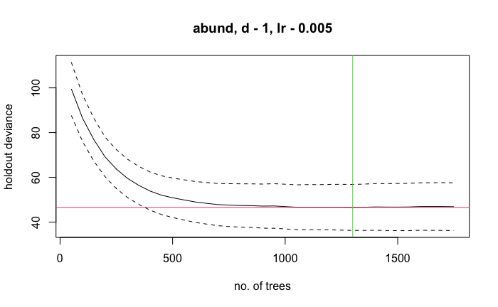

```r
loyn.gbm2 <- gbm.step(gbm.y=1, gbm.x=c(3,6:9), data=loyn, family="gaussian", bag.fraction=0.5, learning.rate=0.005, tree.complexity=1)
```

```r
print(loyn.gbm2)
```

```
gbm::gbm(formula = y.data ~ ., distribution = as.character(family),
    data = x.data, weights = site.weights, var.monotone = var.monotone,
    n.trees = target.trees, interaction.depth = tree.complexity,
    shrinkage = learning.rate, bag.fraction = bag.fraction, verbose = FALSE)
A gradient boosted model with gaussian loss function.
1300 iterations were performed.
There were 5 predictors of which 5 had non-zero influence.
```

**Try more complex tree (complexity=3)**

```
 GBM STEP - version 2.9

Performing cross-validation optimisation of a boosted regression tree model
for abund and using a family of gaussian
Using 56 observations and 5 predictors
creating 10 initial models of 50 trees

 folds are unstratified
total mean deviance =  113.1773
tolerance is fixed at  0.1132
ntrees resid. dev.
50    98.884
now adding trees...
100   86.0671
150   76.4561
200   69.0808
250   63.9834
300   59.8556
350   56.6837
400   54.6266
450   52.715
500   51.432
550   50.515
600   50.0033
650   49.3465
700   49.2181
750   49.2457
800   49.1708
850   49.2536
900   49.1821
950   49.167
1000   49.0252
1050   48.8508
1100   48.9484
1150   48.8864
1200   48.8409
1250   48.9574
1300   48.9999
1350   48.9106
1400   48.7983
1450   48.812
1500   48.761
1550   48.7211
1600   48.8229
1650   48.9358
1700   49.0386
1750   49.1653
1800   49.1264

mean total deviance = 113.177
mean residual deviance = 26.393

estimated cv deviance = 48.721 ; se = 11.369

training data correlation = 0.877
cv correlation =  0.732 ; se = 0.073

elapsed time -  0.01 minutes
```

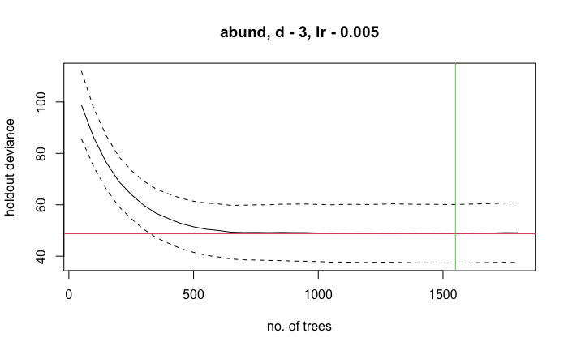

```r
loyn.gbm3 <- gbm.step(gbm.y=1, gbm.x=c(3,6:9), data=loyn, family="gaussian", bag.fraction=0.5, learning.rate=0.005, tree.complexity=3)
```

```r
print(loyn.gbm3)
```

```
gbm::gbm(formula = y.data ~ ., distribution = as.character(family),
    data = x.data, weights = site.weights, var.monotone = var.monotone,
    n.trees = target.trees, interaction.depth = tree.complexity,
    shrinkage = learning.rate, bag.fraction = bag.fraction, verbose = FALSE)
A gradient boosted model with gaussian loss function.
1550 iterations were performed.
There were 5 predictors of which 5 had non-zero influence.
```

**try more complex tree (complexity=4)**

```
 GBM STEP - version 2.9

Performing cross-validation optimisation of a boosted regression tree model
for abund and using a family of gaussian
Using 56 observations and 5 predictors
creating 10 initial models of 50 trees

 folds are unstratified
total mean deviance =  113.1773
tolerance is fixed at  0.1132
ntrees resid. dev.
50    97.7243
now adding trees...
100   85.1598
150   76.2338
200   69.122
250   63.8355
300   60.2532
350   57.1225
400   54.8718
450   53.1288
500   51.8464
550   50.7832
600   50.1007
650   49.7548
700   49.4518
750   49.1935
800   48.8942
850   49.0452
900   49.0204
950   48.9536
1000   48.93
1050   49.0093
1100   49.0488
1150   48.8286
1200   48.7518
1250   48.783
1300   48.8788
1350   48.8562
1400   48.8175
1450   48.7362
1500   48.948
1550   49.0853
1600   49.0755
1650   48.9991
1700   49.2345

mean total deviance = 113.177
mean residual deviance = 26.246

estimated cv deviance = 48.736 ; se = 10.179

training data correlation = 0.879
cv correlation =  0.788 ; se = 0.042

elapsed time -  0.01 minutes
```

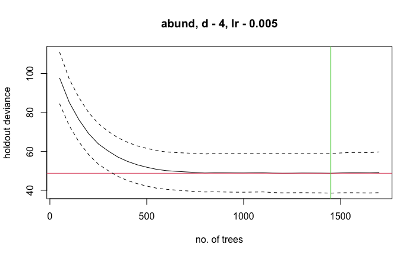

```r
loyn.gbm4 <- gbm.step(gbm.y=1, gbm.x=c(3,6:9), data=loyn, family="gaussian", bag.fraction=0.5, learning.rate=0.005, tree.complexity=4)
```

```r
print(loyn.gbm4)
```

```
gbm::gbm(formula = y.data ~ ., distribution = as.character(family),
    data = x.data, weights = site.weights, var.monotone = var.monotone,
    n.trees = target.trees, interaction.depth = tree.complexity,
    shrinkage = learning.rate, bag.fraction = bag.fraction, verbose = FALSE)
A gradient boosted model with gaussian loss function.
1450 iterations were performed.
There were 5 predictors of which 5 had non-zero influence.
```

**try more complex tree (complexity=5)**

```
 GBM STEP - version 2.9

Performing cross-validation optimisation of a boosted regression tree model
for abund and using a family of gaussian
Using 56 observations and 5 predictors
creating 10 initial models of 50 trees

 folds are unstratified
total mean deviance =  113.1773
tolerance is fixed at  0.1132
ntrees resid. dev.
50    98.6754
now adding trees...
100   86.3589
150   76.8216
200   69.7461
250   64.3986
300   60.4982
350   57.4546
400   54.9405
450   52.8936
500   51.6109
550   50.6183
600   49.8874
650   49.2615
700   48.8659
750   48.6131
800   48.4315
850   48.4276
900   48.3025
950   48.2503
1000   48.1359
1050   48.1406
1100   47.8787
1150   47.8485
1200   47.7282
1250   47.7871
1300   47.7232
1350   47.8267
1400   47.9109
1450   48.0164
1500   47.8552
1550   47.8792
1600   48.0081
1650   48.0077
1700   48.186
1750   48
1800   48.0696

mean total deviance = 113.177
mean residual deviance = 27.523

estimated cv deviance = 47.723 ; se = 10.452

training data correlation = 0.872
cv correlation =  0.777 ; se = 0.04

elapsed time -  0.01 minutes
```

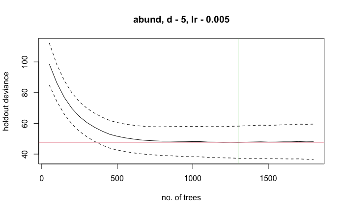

```r
loyn.gbm5 <- gbm.step(gbm.y=1, gbm.x=c(3,6:9), data=loyn, family="gaussian", bag.fraction=0.5, learning.rate=0.005, tree.complexity=5)
```

```r
print(loyn.gbm5)
```

```
gbm::gbm(formula = y.data ~ ., distribution = as.character(family),
    data = x.data, weights = site.weights, var.monotone = var.monotone,
    n.trees = target.trees, interaction.depth = tree.complexity,
    shrinkage = learning.rate, bag.fraction = bag.fraction, verbose = FALSE)
A gradient boosted model with gaussian loss function.
1300 iterations were performed.
There were 5 predictors of which 5 had non-zero influence.
```

## Boosted regression tree - fit chosen model using gbm

|  | var | rel.inf |
| --- | --- | --- |
| logarea | logarea | 53.484140 |
| graze | graze | 18.656666 |
| alt | alt | 13.271297 |
| yearisol | yearisol | 7.687689 |
| logdist | logdist | 6.900208 |

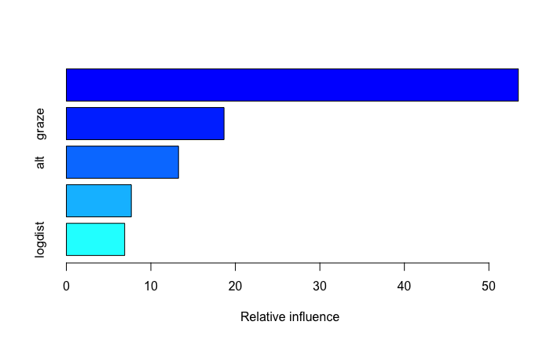

```r
loyn.gbm6 <- gbm(abund~ logarea+logdist+graze+alt+yearisol, data=loyn, n.trees=2000, distribution="gaussian", interaction.depth=2, bag.fraction=0.5, shrinkage=0.005, cv.folds=10)
summary(loyn.gbm6)
```

```r
print(loyn.gbm6)
```

```
gbm(formula = abund ~ logarea + logdist + graze + alt + yearisol,
    distribution = "gaussian", data = loyn, n.trees = 2000, interaction.depth = 2,
    shrinkage = 0.005, bag.fraction = 0.5, cv.folds = 10)
A gradient boosted model with gaussian loss function.
2000 iterations were performed.
The best cross-validation iteration was 1410.
There were 5 predictors of which 5 had non-zero influence.
```

```r
loyn.gbm6
```

```
gbm(formula = abund ~ logarea + logdist + graze + alt + yearisol,
    distribution = "gaussian", data = loyn, n.trees = 2000, interaction.depth = 2,
    shrinkage = 0.005, bag.fraction = 0.5, cv.folds = 10)
A gradient boosted model with gaussian loss function.
2000 iterations were performed.
The best cross-validation iteration was 1410.
There were 5 predictors of which 5 had non-zero influence.
```

**do partial dependence plots one at a time, but not sure what n.trees refers to** partial doesn’t seem to like gbm objects; seems like it’s now done using plot.gbm, with slightly different arguments. Left out n.trees - used package defaults

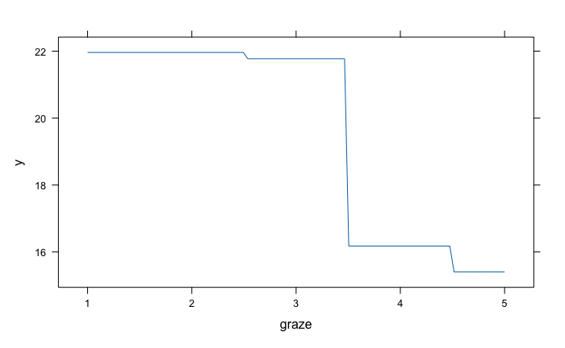

```r
#p2 <- partialPlot(loyn.gbm6, x.var=c("graze"), n.trees=984)
#plot(p2)
plot.gbm(loyn.gbm6, i.var=c("graze"))
```

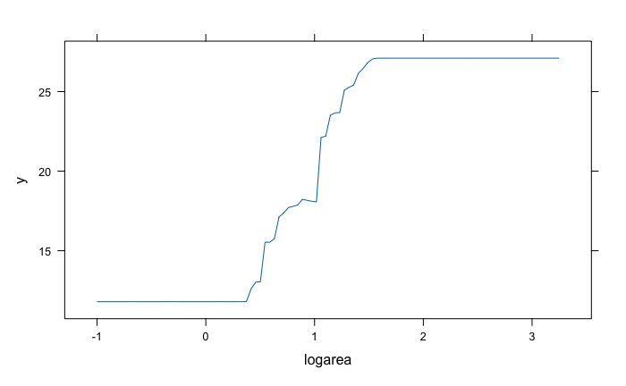

```r
plot.gbm(loyn.gbm6, variable.no=0)
```

```
[1] 1410
```

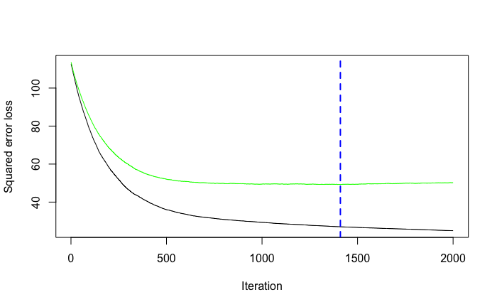

```r
gbm.perf(loyn.gbm6, method="cv")
```